# Blood pressure therapy

Lovdip Singh

## Question of interest/goal of the study

We are interested in seeing if there is a change in the systolic blood pressure (SBP) (preferably a decrease) after the therapy has been administered. As we have a paired design, we want to see if the average difference in SBP is different from 0.

## Read in and inspect the data:

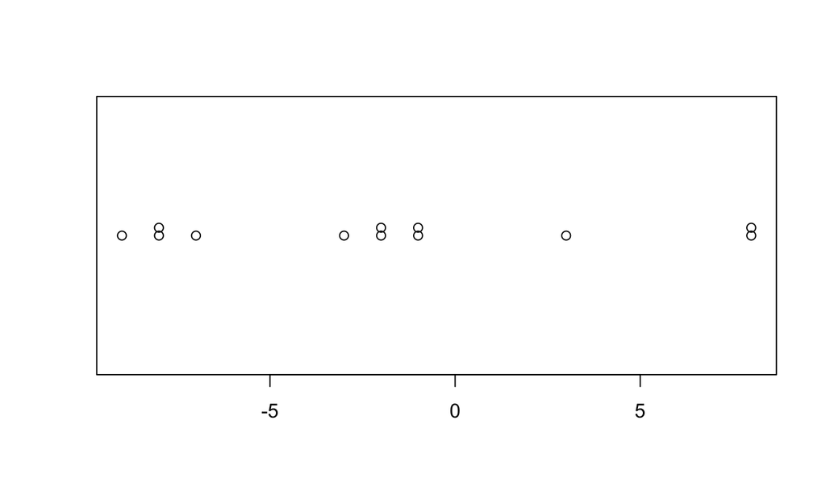

```r
sbp.df=read.table("sbp.txt", header=T)
sbp.differences=sbp.df$before-sbp.df$after
stripchart(sbp.differences,method="stack",pch=1)
```

```r
summaryStats(sbp.differences)
```

```
## Minimum value:           -9
## Maximum value:           8
## Mean value:              -1.83
## Median:                  -2
## Upper quartile:          0
## Lower quartile:          -7.25
## Variance:                33.97
## Standard deviation:      5.83
## Midspread (IQR):         7.25
## Skewness:                0.44
## Number of data values:   12
```

## Manually calculate the t-statistic for testing if the underlying mean is 0, and the 95% confidence interval for the mean.

Formulas: $T = \frac{\bar{y}-\mu_0}{se(\bar{y})}$ and 95% confidence interval $\bar{y} \pm t_{df, 0.975} \times se(\bar{y})$

NOTES: The R code `mean(y)` calculates $\bar{y}$. The standard error is $se(\bar{y}) = \frac{s}{\sqrt{n}}$ where $s$ is the standard deviation of $y$ and is calculated by `sd(y)`, and $n$ is the number of data-points calculated by `length(y)`. The degrees of freedom is $df = n-1$. The $t_{df,0.975}$ multiplier is given by the R code `qt(0.975, df)`.

```r
# t-statistic for H0: mu=0:
n <- length(sbp.differences)
mean(sbp.differences) / (sd(sbp.differences)/sqrt(n))
```

```
## [1] -1.089648
```

```r
# 95% confidence interval for the mean:
tmult <- qt(1 - 0.05/2, df = n - 1)
mean(sbp.differences) + c(-1, 1) * tmult * sd(sbp.differences)/sqrt(n)
```

```
## [1] -5.536492  1.869825
```

## Calculation using t.test function:

```r
t.test(sbp.differences, var.equal=TRUE)
```

```
##
##  One Sample t-test
##
## data:  sbp.differences
## t = -1.0896, df = 11, p-value = 0.2992
## alternative hypothesis: true mean is not equal to 0
## 95 percent confidence interval:
##  -5.536492  1.869825
## sample estimates:
## mean of x
## -1.833333
```

## Fitting the null model

```r
sbp.fit <- lm(sbp.differences ~ 1)
summary(sbp.fit)
```

```
##
## Call:
## lm(formula = sbp.differences ~ 1)
##
## Residuals:
##     Min      1Q  Median      3Q     Max
## -7.1667 -5.4167 -0.1667  1.8333  9.8333
##
## Coefficients:
##             Estimate Std. Error t value Pr(>|t|)
## (Intercept)   -1.833      1.683   -1.09    0.299
##
## Residual standard error: 5.828 on 11 degrees of freedom
```

```r
confint(sbp.fit)
```

```
##                 2.5 %   97.5 %
## (Intercept) -5.536492 1.869825
```

The coeffecient in this linear model is the mean difference between SBP after taking therapy, this was the same as the one calculated using a paired sample independent t-test (comparing SBP before and after therapy). Both were testing the sample mean against the null hypothesis (mean difference before and after therapy = 0). The 95% confidence intervals therefore were also the same at -5.5 to 1.87.

As the data has two measurements (systolic blood pressure before and after the therapy) on each person, we have applied a paired sample t-test to test if there is a change after the therapy.

Our model is: $sbpDiff_i = \mu_{d} + \epsilon_i$ where $\epsilon_i \sim iid ~ N(0,\sigma^2)$

## Executive Summary

We were interested to see if the therapy led to a change in the systolic blood pressure.

We cannot conclude that the therapy will lead to a reduction in systolic blood pressure.